**Nota:** documento construido con base en el video de Julio Trenceti [Criação de pacotes em R](https://www.youtube.com/watch?v=AUjFGd1O8Y0).

# Filosofía

- Todo lo que pueda ser automatizado, debe ser automatizado.
- Uso de la biblioteca `devtools`
- La biblioteca puede ser albergada en Github (no necesariamente en el CRAN)
- Trabajar más en la funcionalidad y menos en la estructura.

# Requisitos

- Bibliotecas
  - `devtools`
  - `roxygen2`
  - `testthat`
  - `knitr`
- R y RStudio actualizados

## Configuración

- Instalar versión `dev` de `devtools`
  - Instalar `devtools`
  - Luego `devtools::install_github("hadley/devtools")`
- Sistemas operativos
  - **Windows:** instalar `Rtools`
  - **Mac:** instalar `XCode`
  - **GNU Linux:** instalar `r-base-dev`
    - `sudo apt-get install r-base-dev`
- Verificar que todo está correcto
  - `devtools:has_devel()`

```r
print(devtools::has_devel())
```

```
## [1] TRUE
```

# Etapas sugeridas para crear una biblioteca de R

- Crear repositorio en el [Github](https://github.com/)
- Clonar en un directorio
- `devtools::setup()`: cargar la configuración básica de un paquete en R
  - Description: metadatos
  - Namespace: interacción del paquete con otros.
  - Carpeta “R” para almacenar los scripts con las funciones
  - man/: carpeta donde está la documentación del paquete

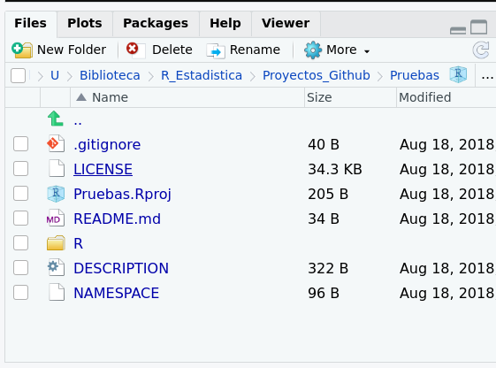

# Componentes del paquete

## Description

- Versión del paquete (`devtools::numeric_version()`)
- Dependencias
- Autor o autores
- Licencias
- Definir `Imports` y `Suggests` con `usethis::use_package("xxx", type = "xxxx")`
  - `Imports`: bibliotecas necesarias o esenciales
  - `Suggests`: bibliotecas sugeridas

## Código R

- Todas los códigos de R deben estar almacenados en la carpeta R
- Todo se organiza a partir de funciones
- Cargar todos los cambios (`devtools::load_all()`)
- **Nota**: no usar funciones como `library()`, `require()`

## Documentación

- Fácil de construir
  - Agregar encabezados a las funciones de R
  - Usar `devtools::document()`
  - Comenzar con `#'`
- Etiquetas con `@tag` (ej. @param)
- Texto
  - Primera sentencia es el título
  - Segunda sentencia es una descripción
  - Las demás sentencias indican detalles múltiples

```r
#' Valor p en múltiples t.test
#'
#' Esta función genera una población de números aleatorios con
#' distribución normal y con base en ella se realizan múltiples
#' muestreos; luego se emplea el t.test para obtener el número de veces que
#' el contraste de hipótesis genera conclusiones erradas.
#'
#' Detalles...
#'
#' @param n tamaño poblacional (por defecto igual a 1000)
#' @param gp tamaño muestral (por defecto igual a 20)
#' @param cp número de comparaciones (por defecto igual a 100)
#' @param nc nivel de confianza (por defecto igual a 0.95)
#'
#' @return un vector con los valores p obtenidos para las comparaciones
#' establecidas.
#'
#' @examples
#' valp(n = 100, gp = 5, cp = 10, nc = 0.90)
#' valp(n = 100, gp = 10, cp = 10, nc = 0.95)
#' valp(n = 100, gp = 15, cp = 10, nc = 0.99)
#'
#' @export
valp <- function(n = 1000, gp = 20,  cp = 100, nc = 0.95){
  pob = rnorm(n = n)
  g1 = list()
  vp = c()
  for (i in 1:cp) {
    g1[[i]] = sample(pob, size = gp)
    vp[i] = t.test(x = g1[[i]], alternative = "two.sided", conf.level = nc,
                   mu = 0)$p.value
  }
  return(vp)
}
```

### Viñetas

- Útil para dar una explicación general de una biblioteca.
- Fácil de construir con RMarkdown.
- Generalmente se usa para bibliotecas más complejas.
- Usar `usethis::use_vignette("nombre")` para crear viñeta (con plantilla RMarkdown)
- Para usar el paquete debe ser instalado mientras se desarrolla, de lo contrario no ejecuta correctamente (por ejemploa al crear las viñetas).

## Pruebas (`testthat`)

- Biblioteca `testthat` de Hadley.
- `devtools::use:testthat()`
- Definir lo que se quiere probar (función o parámetros) y lo que se espera de resultado.
- Ejecutar las pruebas `devtools::test` sobre un nuevo Script que se almacena dentro de la carpeta `testthat`.

```r
library(Pruebas)
context("Longitud del vector resultante")
test_that("Prueba la longitud del vector", {
  expect_equal(length(valp()), 100)
})
```

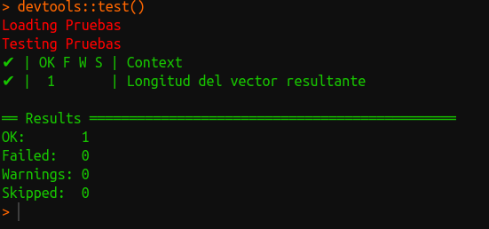

## Namespace

- Puede ser necesario para subir el paquete al CRAN.
- **Imports** y **Exports**
- Use `@export` para hacer que la función quede disponible para el usuario a través de `::`
- Use `@import` para especificar que dicha función (la de su paquete) necesita de otra función que pertenece a otra biblioteca.

```r
#' Valor p en múltiples t.test
#'
#' Esta función genera una población de números aleatorios con
#' distribución normal y con base en ella se realizan múltiples
#' muestreos; luego se emplea el t.test para obtener el número de veces que
#' el contraste de hipótesis genera conclusiones erradas.
#'
#' Detalles...
#'
#' @param n tamaño poblacional (por defecto igual a 1000)
#' @param gp tamaño muestral (por defecto igual a 20)
#' @param cp número de comparaciones (por defecto igual a 100)
#' @param nc nivel de confianza (por defecto igual a 0.95)
#'
#' @return un vector con los valores p obtenidos para las comparaciones
#' establecidas.
#'
#' @examples
#' valp(n = 100, gp = 5, cp = 10, nc = 0.90)
#' valp(n = 100, gp = 10, cp = 10, nc = 0.95)
#' valp(n = 100, gp = 15, cp = 10, nc = 0.99)
#'
#' @export
valp <- function(n = 1000, gp = 20,  cp = 100, nc = 0.95){
  pob = rnorm(n = n)
  g1 = list()
  vp = c()
  for (i in 1:cp) {
    g1[[i]] = sample(pob, size = gp)
    vp[i] = t.test(x = g1[[i]], alternative = "two.sided", conf.level = nc,
                   mu = 0)$p.value
  }
  return(vp)
}
```

```r
#' Gráfico de valores p en t.test
#'
#' Gráfico de valores p obtenido con valp.
#'
#' @param x vector de valores p con la función \code{\link{valp}}
#'
#' @examples
#' grafvp(valp()) # 100 comparaciones por defecto
#' grafvp(valp(cp = 10)) # modificando el número de comparaciones
#'
#' @importFrom stats rnorm t.test
#'
#' @export
#' @import ggplot2
grafvp <- function(x) {
  df = data.frame(index = c(1:length(x)), valorP = x)
  g = ggplot(data = df, aes(x = index, y = valorP)) +
    geom_point() +
    geom_hline(yintercept = 0.01, lwd = 0.5, color = "firebrick", lty = 2) +
    geom_hline(yintercept = 0.05, lwd = 0.5, color = "dodgerblue4", lty = 2) +
    geom_hline(yintercept = 0.10, lwd = 0.5, color = "green4", lty = 2) +
    labs(x = "", y = "Valor p",
         title = paste0("Valores p para ", length(x), " comparaciones",
                        sep = ""),
         caption = "Línea roja: 0.01\nLínea azul: 0.05\nLínea verde: 0.10") +
    theme_linedraw()
  return(g)
}
```

## Datos externos

- Cuatro maneras de incluir datos en un paquete
  - Binarios (.Rdata) en la carpeta **data/**. Usar `devtools::use_data()`
  - Datos utilizados internamente por las funciones en **R/sysdata.rda**
  - Datos en texto (csv, txt, excel) en la carpeta **inst/extdata**
  - Datos que no son utilizados por el paquete en **data-raw**. Usar `devtools::use_data_raw()`
- Documentar los datos es semejante a documentar las funciones adicionando **@format** y **@source**
- No es necesario unsar **@export**

## Código compilado (C, C++)

- Usar el paquete `Rcpp`
- Programar en **C** o **C++**
- Usando R o RStudio y abriendo un nuevo archio, es posible visualizar un prototipo.
- Usar *CTRL + Shift + B* en lugar de `devtools::load_all()`

## Comprobar paquete con `devtools::check()`

- Con `devtools::check()` se obtienen:
  - Errores
  - Advertencias
  - Anotaciones

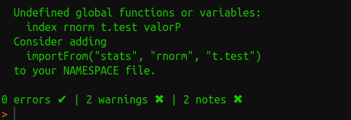

Finalmente, sin errores, el paquete podrá ser almacenado en Github.

# Probando el paquete “Pruebas”

- **Instalación:**

```r
devtools::install_github("Edimer/Pruebas", force = TRUE)
```

- **Usando la función `valp()`:** en este caso se realizan 100 comparaciones (nivel de confianza del 95%) para muestras de tamaño 1000, obtenidas de una población (tamaño de 1 millón) con distribución normal estándar (media cero y desviación igual a 1).

```r
library(Pruebas)
valores <- valp(n = 1000000, gp = 1000, cp = 100, nc = 0.95)
```

- **Usando la función `grafvp()`:** se grafican los 100 valores p obtenidos en el paso anterior (almacenado en el vector `valores`).

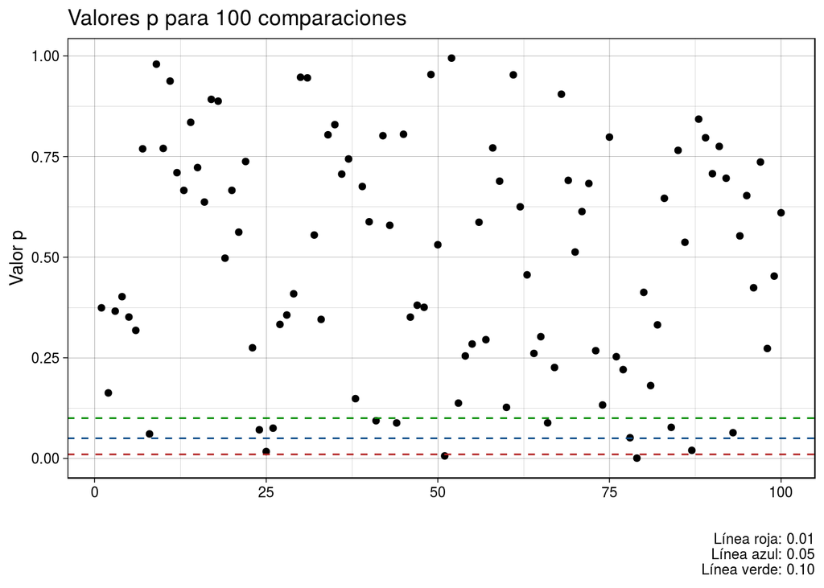

```r
set.seed(1000)
library(ggplot2)
grafvp(valores)
```